# Extending The SEIR Model: A Monte Carlo Study

### April 21, 2020

## Model Definition

The SEIR model is a standard mathematical model from epidemiology for modeling the outbreak of an infectious disease in a given population. The basic model consists of four states - suceptible (S), exposed (E), infectious (I), and removed (R). A susceptible individual becomes exposed to the virus through contact with infectious individuals, and so progresses from S to E. At disease onset the individual moves to state I, and upon recovery or death they move to R. Model parameters determine the rate of transfer between each state.

The SEIR model can be extended by including additional states and parameters which help to more fully capture the complexity of a particular outbreak. One example of this kind of extended SEIR model is presented in [Kissler et al. 2020](https://www.medrxiv.org/content/10.1101/2020.03.22.20041079v1.full.pdf). Their model stratifies cases by severity - that is, after exposure an individual either becomes a mild/asymptomatic, severe, or critical case. Mild/asymptomatic cases require no hospitalization, severe cases require hospitalization but no critical care, and critical cases require hospitalization including critical care. Mild/asymptomatic cases move straight from the infectious state to the removed state. Severe cases move from the infectious state to the non-critical hospitalization state, then to removed. Critical cases move from the infectious state to hospitalization, to ICU, to removed.

The states, paths, and parameters for the Kissler model are depicted here (diagram and table directly from the paper):

[figure not shown]

## Notebook Objectives

In this notebook we do the following:

1. Implement the model from the Kissler paper
2. Extend the model by treating parameters as random variables
3. Use monte carlo methods with the stochastic model to generate a more robust forecast

First we import the necessary libraries.

```python
# imports
import math
import matplotlib.pyplot as plt
import pandas as pd
import numpy as np
import numpy.random as R
```

## 1. Implementing the Kissler model

Here we implement the model as a python class with attributes for storing initial conditions, parameter values, statistics of interest, and the simulated outbreak as a time-series. We define intuitive methods for interfacing with the model - `KisslerModel.run()` and `KisslerModel.summarize()`. After instantiating a model with a set of initial conditions, simply run these commands to generate and visualize a simulation.

```python
class KisslerModel:
    """
    this class implements the Kissler model;
    see: https://www.medrxiv.org/content/10.1101/2020.03.22.20041079v1.full.pdf
    """

    # list all states of the model
    states = [
        "S",
        "E",
        "Ir", "Rr",
        "Ih", "Hh", "Rh",
        "Ic", "Hc", "Cc", "Rc"
    ]

    def __init__(self, initVals=None, nSteps=150):

        # store number of timesteps to simulate
        self.nSteps = nSteps

        # store initial values if provided
        self.initVals = initVals

        # store param values after draw/assign
        self.params = KisslerParameters()

        # store per-state time-series generated by model run
        self.simulation = {}

        # store statistics computed from simulation data
        self.stats = {}

    def monteCarlo(self, n):
        simulations = []
        statistics = []
        for i in range(n):
            model = KisslerModel(self.initVals)
            model.run(stochastic=True)
            simulations.append(model.simulation)
            statistics.append(model.stats)

        # average the statistics
        self.stats = pd.concat(statistics, axis=1).mean(axis=1)

        # average the time-series
        self.simulation = pd.concat(simulations, keys=[i for i in range(n)]).mean(level=1)

    def run(self, stochastic=False):
        """
        1. assign values to parameters
        2. run the simulation
        3. compute statistics
        """

        if stochastic:
            self.params.draw()
        else:
            self.setParams()

        self.runSimulation()
        self.computeStats()

    def setParams(self):
        """set param values to fixed (i.e., non-random) values from the paper"""
        self.params.vals = {
            "maxR0": 2, "seasonal": .7, "phi": -26.6,  # beta is a cosine fn defined by these params
            "v": .217,                                 # inverse of mean incubation period
            "pr": .956, "ph": .0308, "pc": .0132,      # rel freq of cases mild/asymptomatic, hospitalized, critical care
            "gamma": .2,                               # inverse of mean infectious period
            "deltah": .125, "deltac": .167,            # inverse of mean non-icu hospital stay for hospitalized, critical care
            "xic": .1                                  # inverse of mean critical care duration
        }

    def computeStats(self):
        """
        compute statistics of interest from simulation results
            - size of peak
            - time of peak
            - how much of the population gets sick by the end of the outbreak
            - duration of outbreak
            - herd immunity threshold (1 - 1/R0)
                -> see: https://watermark.silverchair.com/cir007.pdf
            - time at which herd immunity threshold reached
            - time at which 50% of the population is recovered/removed
        """

        infectionStates = [
            "E",
            "Ir",
            "Ih", "Hh",
            "Ic", "Hc", "Cc"
        ]

        removedStates = [
            "Rr",
            "Rh",
            "Rc"
        ]

        df = pd.DataFrame.from_dict(self.simulation)
        totalActiveCases = df[infectionStates].sum(axis=1)
        totalRemovedCases = df[removedStates].sum(axis=1)

        # peak stats
        peak_size = totalActiveCases.max()
        peak_time = totalActiveCases.idxmax()

        # here arbitrarily defining "end of outbreak" as
        # when fewer than 1% of the population are active cases
        outbreak_duration = totalActiveCases[peak_time:].lt(.01).idxmax() + peak_time

        # how much of the population will have been infected by the end of the outbreak
        long_run_removed = totalRemovedCases.array[-1]

        # first time at which 50% of the population have had the infection
        half_removed_time = totalRemovedCases.ge(.5).idxmax()

        # herd immunity value and timepoint
        herd_immunity_threshold = 1 - 1/self.params.vals["maxR0"]
        herd_immunity_time = totalRemovedCases.ge(herd_immunity_threshold).idxmax()

        self.stats = pd.DataFrame.from_dict({
            "peak_size": [peak_size],
            "peak_time": [peak_time],
            "outbreak_duration": [outbreak_duration],
            "long_run_removed": [long_run_removed],
            "half_removed_time": [half_removed_time],
            "herd_immunity_threshold": [herd_immunity_threshold],
            "herd_immunity_time": [herd_immunity_time]
        }, orient='index', columns=[""])

    def initStates(self):
        """assign initial relative frequency to each state"""
        freq = {}
        for state in self.states:
            freq[state] = [self.initVals[state]]
        return freq

    def runSimulation(self):
        """
        given:
            - initial conditions set
            - parameter values set

        run the simulation
        """

        # set initial conditions
        freq = self.initStates()

        # retrieve parameter values
        p = self.params.vals
        maxR0, seasonal, phi = p["maxR0"], p["seasonal"], p["phi"]
        v, pr, ph, pc = p["v"], p["pr"], p["ph"], p["pc"]
        gamma = p["gamma"]
        deltah, deltac = p["deltah"], p["deltac"]
        xic = p["xic"]

        # define beta (the cosine fn) using provided params: maxR0, seasonal, phi
        def betaFunc(j):
            return math.cos((2*math.pi*(j + phi))/364)*maxR0*(1-seasonal)/2 + maxR0*(1+seasonal)/2

        # define increment per state for a given time step
        # increment is the difference between the jth and (j+1)th step
        def increment(j):
            beta = betaFunc(j)
            return {
                "S": -beta*freq["S"][j]*(freq["Ir"][j] + freq["Ih"][j] + freq["Ic"][j]),
                "E": beta*freq["S"][j]*(freq["Ir"][j] + freq["Ih"][j] + freq["Ic"][j]) - v*freq["E"][j],
                "Ir": pr*v*freq["E"][j] - gamma*freq["Ir"][j],
                "Rr": gamma*freq["Ir"][j],
                "Ih": ph*v*freq["E"][j] - gamma*freq["Ih"][j],
                "Hh": gamma*freq["Ih"][j] - deltah*freq["Hh"][j],
                "Rh": deltah*freq["Hh"][j],
                "Ic": pc*v*freq["E"][j] - gamma*freq["Ic"][j],
                "Hc": gamma*freq["Ic"][j] - deltac*freq["Hc"][j],
                "Cc": deltac*freq["Hc"][j] - xic*freq["Cc"][j],
                "Rc": xic*freq["Cc"][j]
            }

        # simulate the specified number of timesteps
        for t in range(self.nSteps):
            diffEq = increment(t)
            for state in self.states:
                val = freq[state][t] + diffEq[state]
                freq[state].append(val)


        self.simulation = pd.DataFrame(freq)

    def visualize(self):
        """visualize time-series of relative frequency per state"""
        fig, ax = plt.subplots()
        fig.set_size_inches(16, 8)

        t = [i for i in range(self.nSteps+1)]
        for state in self.states:
            ax.plot(t, self.simulation[state], label=state)

        ax.set(
            xlabel="days",
            ylabel="relative frequency",
            title="relative frequency per state over time"
        )
        ax.legend()
        ax.grid()

        plt.show()

    def summarize(self):
        '''view simulation results'''
        self.visualize()
        print('Statistics of Interest:\n')
        print(self.stats.to_string())
```

### Running the model

Here we define a set of initial conditions to provide to the model, then run the simulation. This initial run of the model uses the parameter values from the Kissler paper as shown in the table at the beginning of this notebook.

```python
# population size
N = 1000000

# initial relative frequency for each state
initVals = {
    "S": 1 - 1/N,
    "E": 1/N,
    "Ir": 0, "Rr": 0,
    "Ih": 0, "Hh": 0, "Rh": 0,
    "Ic": 0, "Hc": 0, "Cc": 0, "Rc": 0
}
```

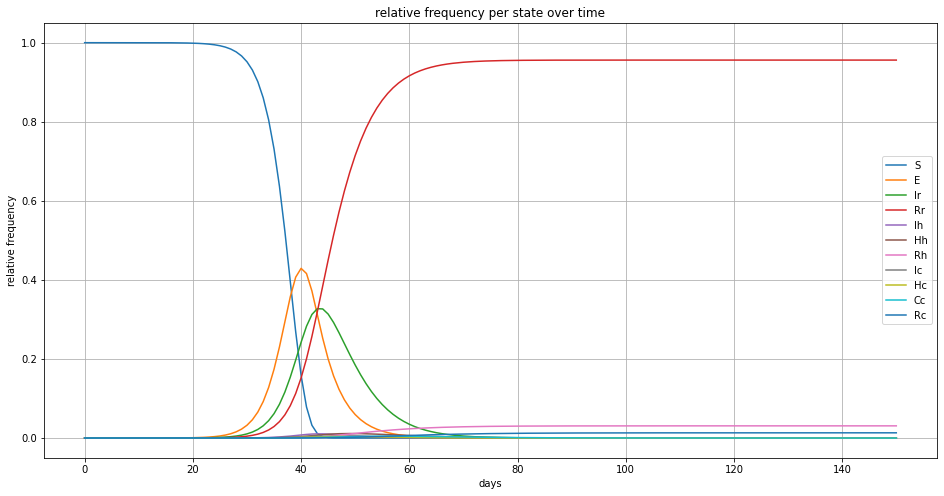

```
Statistics of Interest:


peak_size                  0.719186
peak_time                 41.000000
outbreak_duration        112.000000
long_run_removed           0.999998
half_removed_time         46.000000
herd_immunity_threshold    0.500000
herd_immunity_time        46.000000
```

```python
# run the model and visualize results
model = KisslerModel(initVals)
stats = model.run()
model.summarize()
```

## 2. Making it a stochastic model

As we are in the early stages of the pandemic, it can be difficult to accurately estimate model parameters - for example, the incubation period, duration of infectiousness, or basic reproductive number. One way to account for this uncertainty is to treat model parameters as random variables, each following a distribution which is either fitted to data or otherwise defined to reflect the research community's current knowledge and expectations regarding that parameter.

Here we define the `KisslerParameters` class which serves as a stochastic extension to the Kissler model. Now when we run the model we can specify that we'd like to run the stochastic model, and each time we run it we draw from the parameter distributions. That is to say, each time we run the stochastic model we get a different result.

```python
class KisslerParameters():
    '''handles sampling from parameter distributions'''

    def __init__(self):
        self.vals = {}
        self.distributions = {
            "uniform":[
                {
                    "name": "R0",
                    "a": 2,
                    "b": 2.5
                }
            ],
            "triangular": [
                {
                    "name": "Seasonal Forcing Effect",
                    "a": .7,
                    "m": .8,
                    "b": 1
                },
                {
                    "name": "Proportion of Mild/Asymptomatic Cases",
                    "a": .75,
                    "m": .80,
                    "b": .85
                },
                {
                    "name": "Proportion of Severe Cases",
                    "a": .12,
                    "m": .138,
                    "b": .15
                },
                {
                    "name": "Proportion of Critical Cases",
                    "a": .03,
                    "m": .047,
                    "b": .06
                }
            ],
            "weibull": [
                {
                    "name": "Incubation Period",
                    "alpha": 2.16,
                    "beta": 4.1
                },
                {
                    "name": "Infectious Period",
                    "alpha": 1.8,
                    "beta": 3.37
                },
                {
                    "name": "LOS Non-Critical",
                    "alpha": 3.88,
                    "beta": 7.78
                },
                {
                    "name": "LOS Pre-Critical",
                    "alpha": 1.31,
                    "beta": 5.39
                },
                {
                    "name": "LOS Critical",
                    "alpha": 3.76,
                    "beta": 9.98
                }
            ]
        }

    def draw(self):
        """assign value to each model parameter by drawing from that parameter's distribution"""

        self.vals = {
            "phi": -26.6, # fixed

            "maxR0": self.drawR0()[0],
            "seasonal": self.drawSeasonal()[0],
            "v": 1/self.drawIncubation()[0],
            "gamma": 1/self.drawInfectious()[0],
            "deltah": 1/self.drawLOSNoCritical()[0],
            "deltac": 1/self.drawLOSPreCritical()[0],
            "xic": 1/self.drawLOSCritical()[0]
        }

        self.vals["pr"], self.vals["ph"], self.vals["pc"] = self.drawStrataFreqs()[0]

    def drawR0(self, n=1):
        '''the basic reproductive number'''
        return R.uniform(2,2.5,n)

    def drawSeasonal(self, n=1):
        '''size of effect of seasonal forcing'''
        return R.triangular(.7,.8,1,n)

    ## NOTE: the weibull distributions are shifted so as to
    ## begin at 1 rather than 0, since these rate parameters
    ## cannot have values smaller than the size of the model timestep.
    ## this ensures that the signal between states is never amplified
    ## e.g., 5 people in exposed -> 7 people become infectious
    ## this is an impossible situation in reality,
    ## and it is avoided in the model by this shifting of these distributions

    def drawIncubation(self, n=1):
        '''exposure to onset'''
        return R.weibull(2.16,n)*4.1 + 1

    def drawInfectious(self, n=1):
        '''length of infectious period / onset to hospitalization'''
        return R.weibull(1.8,n)*3.37 + 1

    def drawLOSNoCritical(self, n=1):
        '''length of hospital stay with no visit to the ICU'''
        return R.weibull(3.88,n)*7.78 + 1

    def drawLOSPreCritical(self, n=1):
        '''length of hospital stay prior to transfer to ICU'''
        return R.weibull(1.31,n)*5.39 + 1

    def drawLOSCritical(self, n=1):
        '''duration of critical care'''
        return R.weibull(3.76,n)*9.98 + 1

    def drawStrataFreqs(self, n=1):
        '''relative frequency of each stratum - mild / severe / critical'''

        samples = []
        for _ in range(n):

            # draw percentages
            mild = R.triangular(75,80,85)
            severe = R.triangular(12,13.8,15)
            critical = R.triangular(3,4.7,6)

            # scale
            total = mild + severe + critical
            m, s, c = mild / total, severe / total, critical / total

            samples.append((m,s,c))

        return samples

    def visualize(self):
        '''visualize all parameter distributions in a paneled plot'''
        fig, axs = plt.subplots(5, 2, figsize=(15,22))
        idx = [(j, k) for j in range(5) for k in range(2)]
        i = 0
        for w in self.distributions["weibull"]:
            x = np.linspace(1,20,200)
            axs[idx[i]].plot(x, self.weibull(x, w["alpha"], w["beta"], 1))
            axs[idx[i]].set_title(w["name"])
            i+=1
        for u in self.distributions["uniform"]:
            x = np.linspace(0,5,200)
            axs[idx[i]].plot(x, self.uniform(x, u["a"], u["b"]))
            axs[idx[i]].set_title(u["name"])
            i+=1
        for t in self.distributions["triangular"]:
            x = np.linspace(0,1,200)
            axs[idx[i]].plot(x, self.triangular(x, t["a"], t["m"], t["b"]))
            axs[idx[i]].set_title(t["name"])
            i+=1
        plt.show()

    def weibull(self, x, alpha, beta, offset):
        '''for plotting a shifted weibull distribution'''
        return (alpha / beta) * ((x - offset)/ beta)**(alpha - 1) * np.exp(-((x - offset) / beta)**alpha)

    def triangular(self, x, a, m, b):
        '''for plotting a triangular distribution'''
        y = []
        for i in x:
            if a <= i < m:
                img = 2*(i-a)/((b-a)*(m-a))
            elif m <= i <= b:
                img = 2*(b-i)/((b-a)*(b-m))
            else:
                img = 0
            y.append(img)
        return y

    def uniform(self, x, a, b):
        '''for plotting a uniform distribution'''
        y = np.copy(x)
        y[y < a] = 0
        y[y > b] = 0
        y[y != 0] = 1/(b-a)
        return y
```

### Parameter Distributions

Each of these weibull distributions was tuned to yield the given mean. Each is a shifted weibull, so that the smallest possible value is 1 rather than 0 since the smallest possible timestep in the model is 1. Note that these values are measured in days. The target mean for each distribution is the value used by Kissler and others in their paper. We chose to use the weibull distribution here since it is commonly used to model length-of-stay (LOS). The notation here follows the pattern: weibull(shape, scale), leaving the shift implied since it's been explained and each of them has the same shift.

- Incubation Period ~ weibull(2.16, 4.1); mean = 4.6
- Infectious Period ~ weibull(1.8, 3.37); mean = 4
- LOS Non-Critical ~ weibull(3.88, 7.78); mean = 8
- LOS Pre-Critical ~ weibull(1.31, 5.39); mean = 6
- LOS Critical ~ weibull(3.76, 9.98); mean = 10

We give R0 a uniform distribution which matches the range of values considered by Kissler and others in their paper.

- R0 ~ uniform(2, 2.5); mean = 2.25

Here we visualize all these distributions:

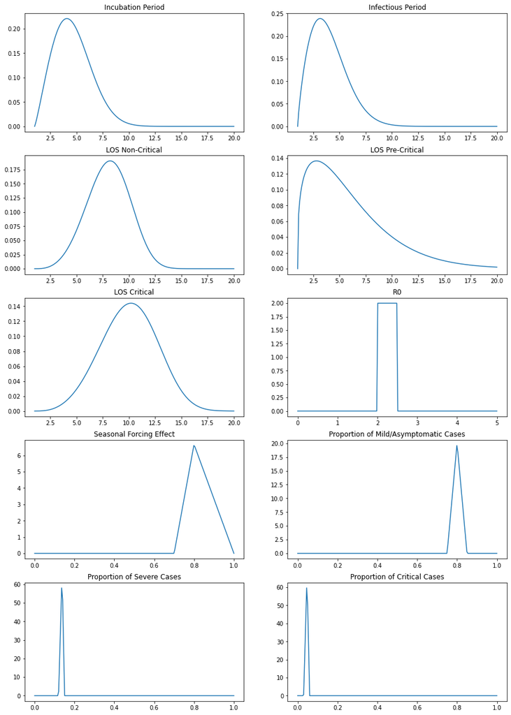

```python
# show parameter distributions
KisslerParameters().visualize()
```

### Run the stochastic model

Now we run the stochastic model three times and visualize the results of each run. We note that each simulation yields different results.

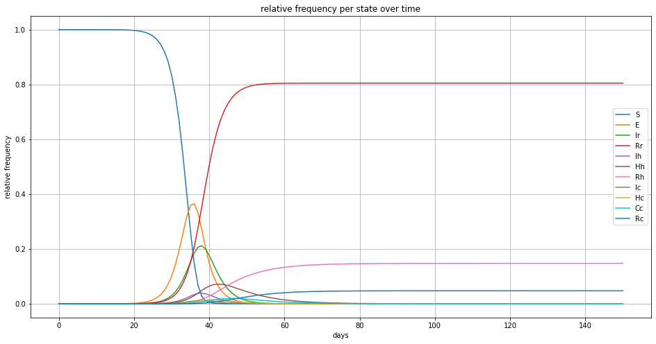

```
Statistics of Interest:


peak_size                  0.642438
peak_time                 37.000000
outbreak_duration        104.000000
long_run_removed           0.999735
half_removed_time         40.000000
herd_immunity_threshold    0.572518
herd_immunity_time        41.000000
```

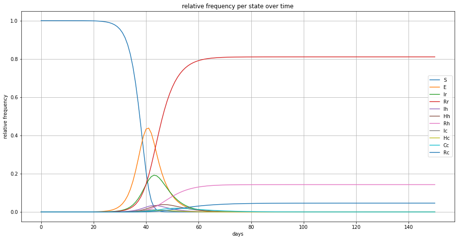

```
Statistics of Interest:


peak_size                  0.676699
peak_time                 42.000000
outbreak_duration        112.000000
long_run_removed           0.999945
half_removed_time         46.000000
herd_immunity_threshold    0.592515
herd_immunity_time        47.000000
```

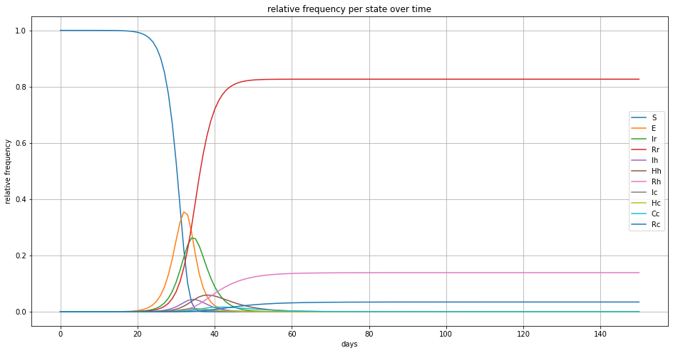

```
Statistics of Interest:


peak_size                 0.666755
peak_time                33.000000
outbreak_duration        90.000000
long_run_removed          0.999947
half_removed_time        36.000000
herd_immunity_threshold   0.569576
herd_immunity_time       37.000000
```

```python
# run the stochastic model three times, view results for each run
model = KisslerModel(initVals)
for i in range(3):
    model.run(stochastic=True)
    model.summarize()
```

## 3. Monte Carlo

Now that we have a stochastic model and obtain different results per run, we'd like to know the expected value for these forecasted statistics of interest, as well as for the progression of the outbreak itself. We can approximate these expected values by running the simulation many times and then averaging the results. This monte carlo routine is implemented in the method `KisslerModel.monteCarlo(n)`, where `n` is the number of times to perform the experiment (where "performing the experiment" in this case means running the simulation).

Here we run the monte carlo routine with `n=10000`.

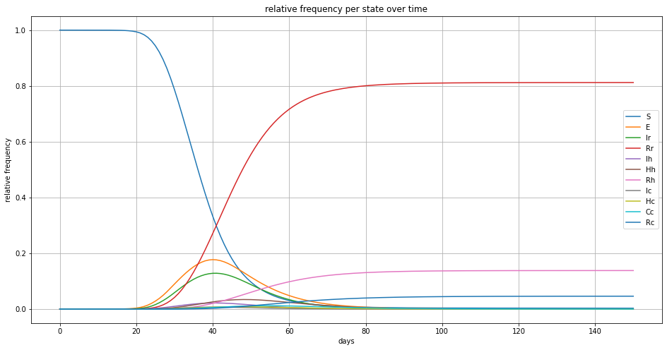

```
Statistics of Interest:

peak_size                    0.686433
peak_time                   41.954800
outbreak_duration          121.872400
long_run_removed             0.996651
half_removed_time           46.987100
herd_immunity_threshold      0.554165
herd_immunity_time          47.942100
```

```python
# run the stochastic model 10000 times, compute expected value, visualize results
model = KisslerModel(initVals)
model.monteCarlo(10000)
model.summarize()
```